# Used Car Price Determinents

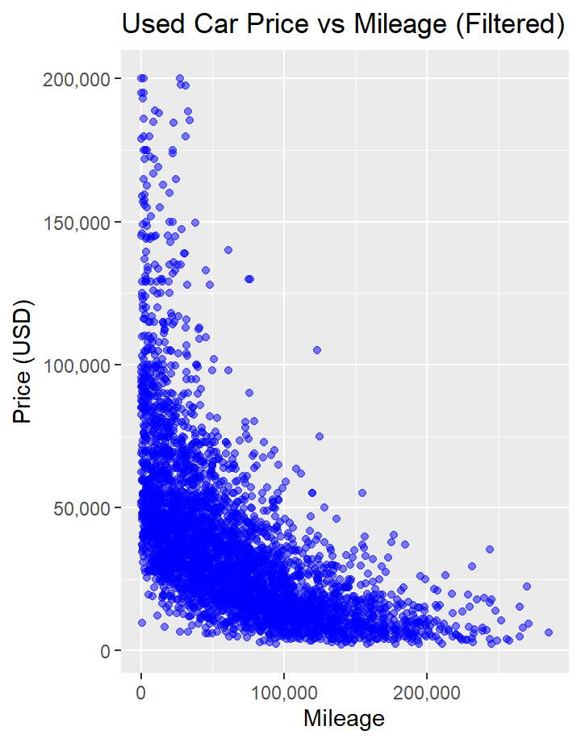

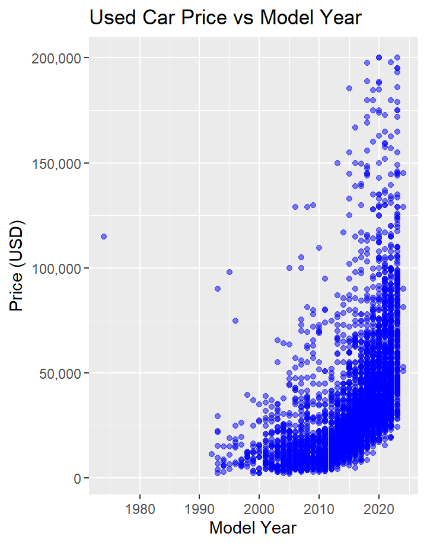

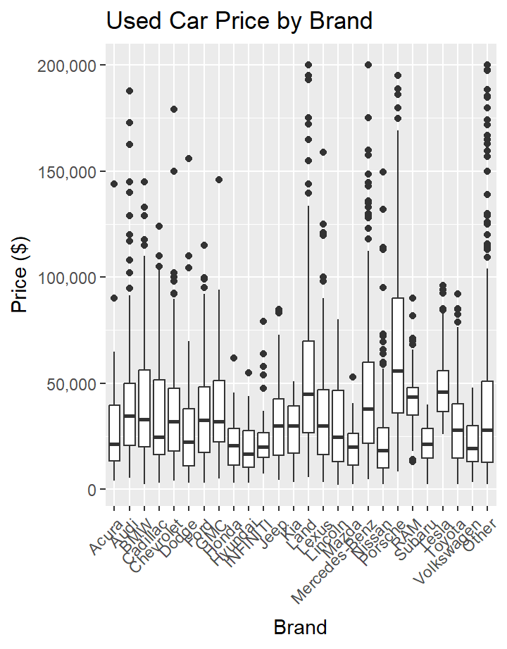

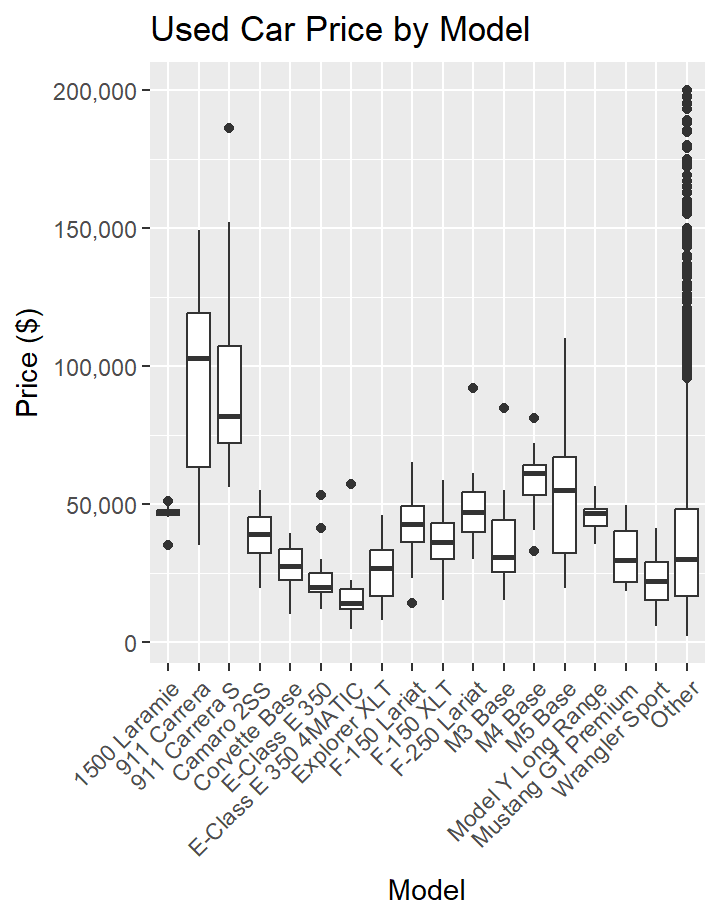

[figure not shown]

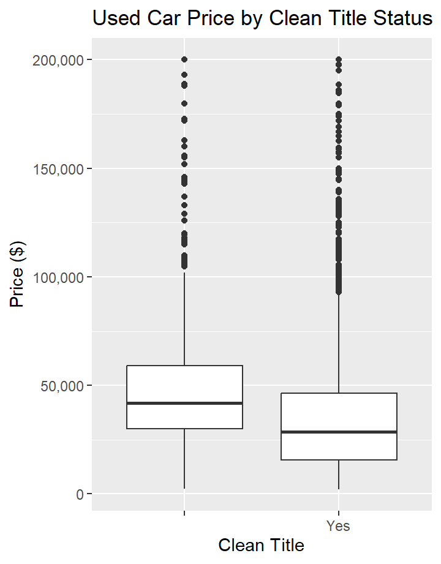

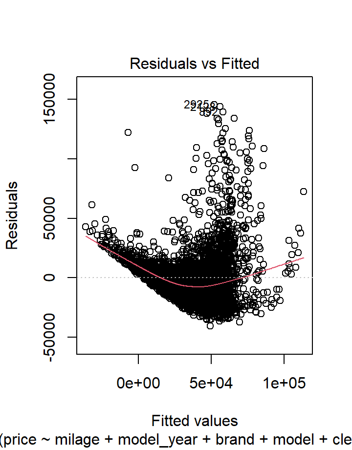

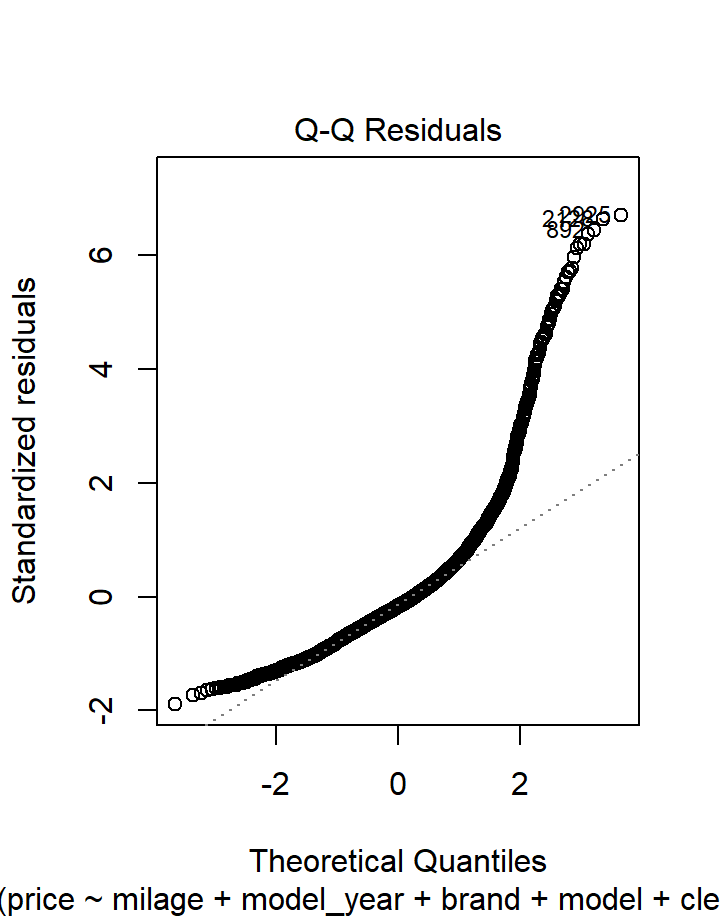

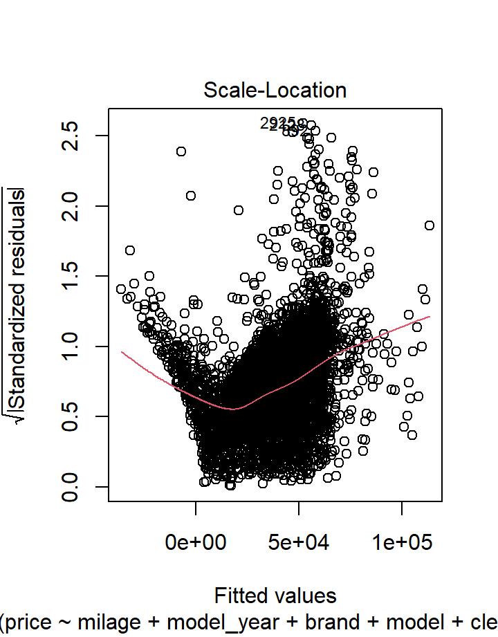

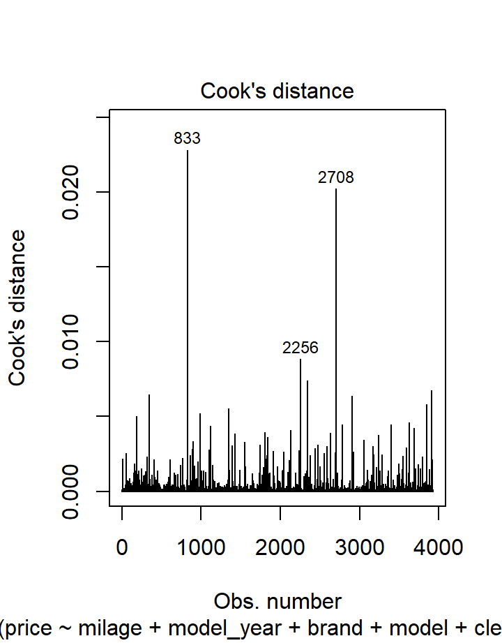

# Introduction

### Price vs Mileage

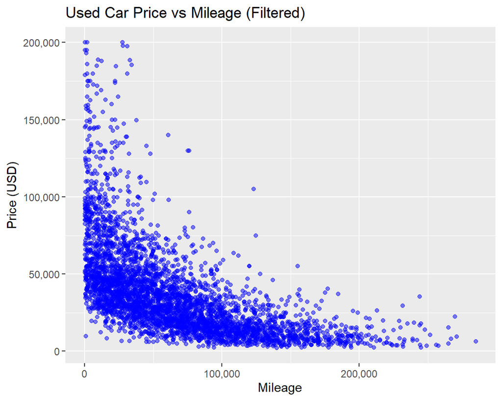

### Price vs Model Year

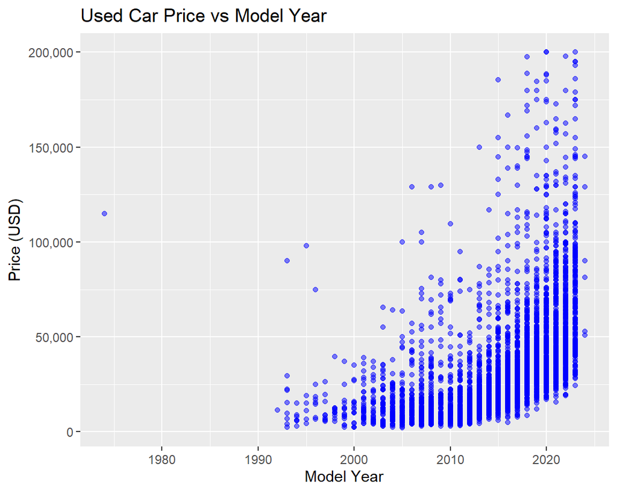

### Price vs Brand

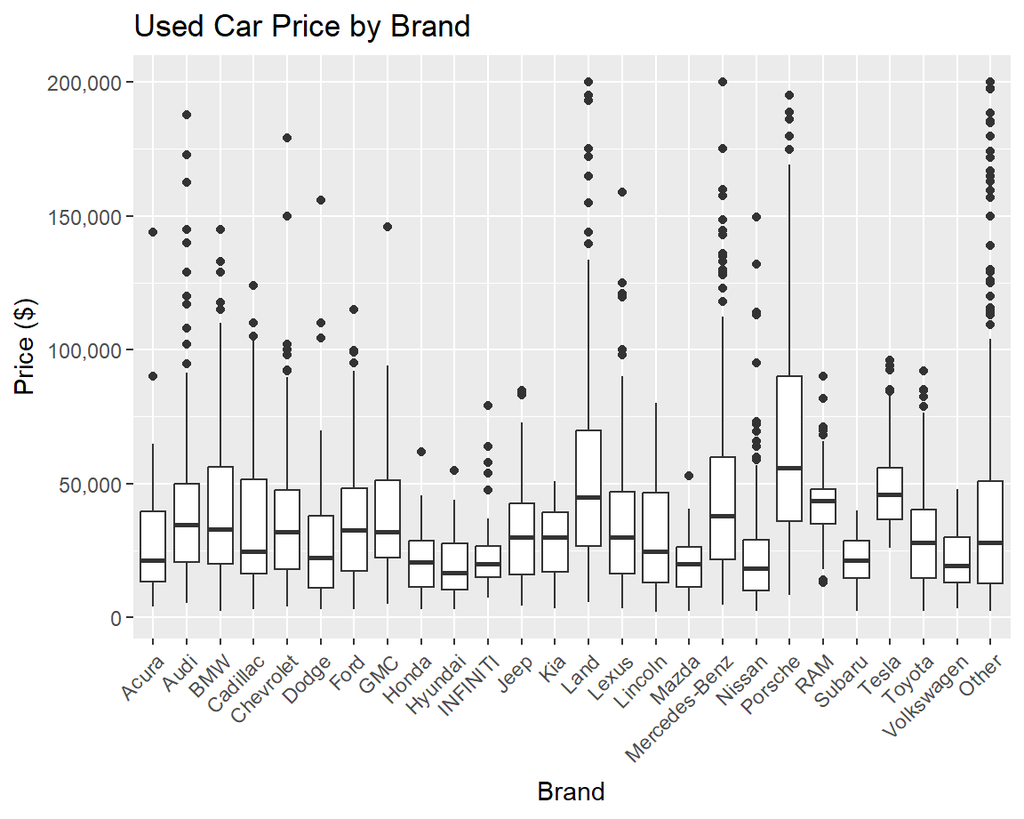

### Price vs Model

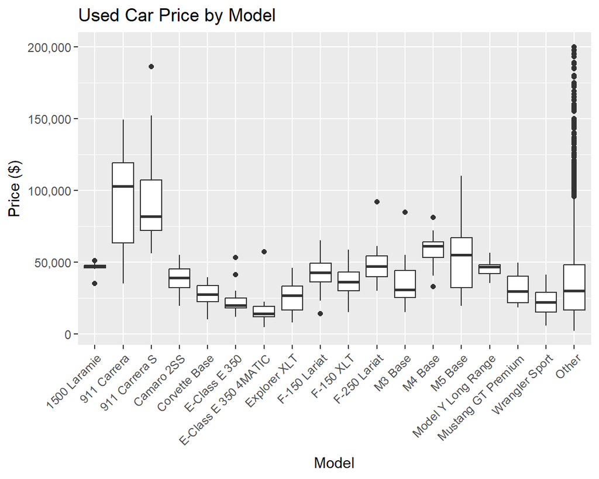

### Price vs Accident History

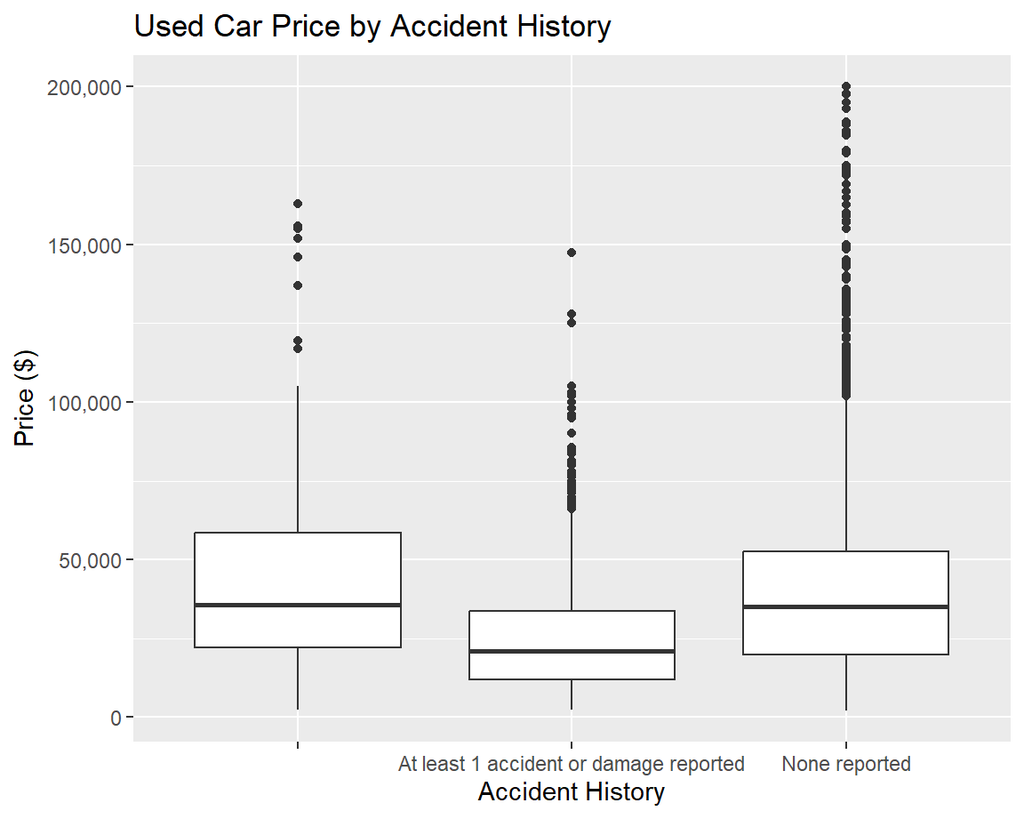

### Price vs Title Status

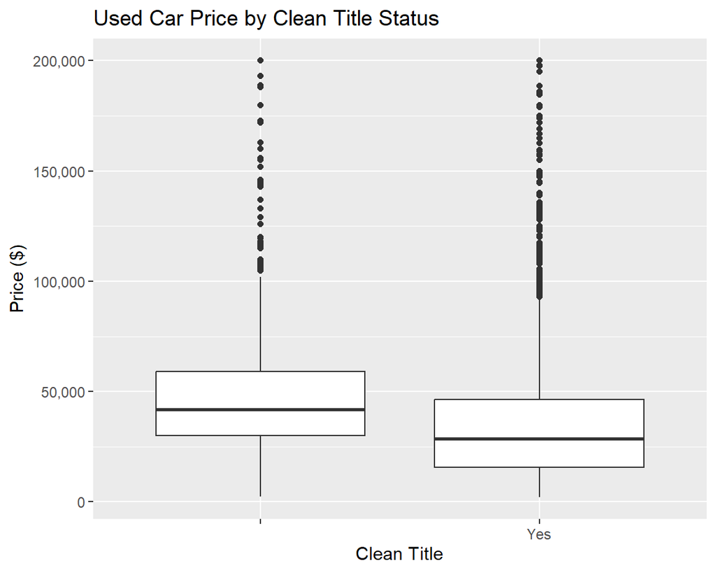

### Introduction

**Motivation** For many college students, they have either never bought a car before or have never bought a car without the help of their parents. The used car market is a massive sea of confusing, inconsistent, and untruthful decisions. As a result of this, first time buyers risk getting ripped off and overpaying or choosing a vehicle that may not be reliable. By building a data driven regression model to predict used car prices, I aim to give the youth or first time buyers of America a leg up on negotiation and an understanding of what a fair price should look like.

# Data

### Key Variables

- price (listed sale price)
- milage (mileage of the vehicle)
- model_year (year manufactured)
- brand (manufacturer)
- model (car model)
- accident (accident history)
- clean_title (clean or salvage title)
- exterior color
- interior color

### Exploratory Data Analysis

**Price vs Mileage:** Showed a strong negative trend, meaning that cars with a higher mileage tend to have lower price suggesting a nonlinear relationship. With a regression coefficient of (-0.258), this showed to be one of the strongest predictors of used car price.

**Price vs Model Year:** Showed that newer vehicle tended to have higher costs compared to older vehicles. The regression coefficient for model year, (1112.7), supports this meaning that for each addition year closer to brand new, the price is expected to increase by 1112.7 USD

**Mileage vs Model Year:** There is a strong negative relationship between model year and mileage with every 1 year increase in a car’s model year, the mileage decreases by about 5,206 miles on average. This reinforces that because model year and mileage are both related, they affect used car price in a very similar way.

### Data Cleaning

**Price Vs Mileage:** The milage (mileage) and price columns contained non numeric characters such as “mi.” and “$,” which prevented me from using a numerical analysis. I used R’s gsub() function to remove all these characters and just leave the numerical data. This allowed me to plot a proper graph

**Brand and Model Names:** The data set contained many brands of cars and 1898 unique model names which made making a clean looking graph impossible. Brands and model names were lumped using fct_lump_n() to keep the most frequent categories and grouping the less common ones into an overall “other” category. This reduced noise on the x-axis and allowed the model to focus on the most important brands and models.

**Converting Categorical Variables to Factors:** Columns such as brand, model, and clean_title were converted to factors to be properly interpreted in regression analysis. This ensured that R treated these variables as categorical, which is required for multiple linear regression

# Diagnostics

### Diagnostics

**Residuals vs Fitted** The Residuals vs Fitted plot evaluates whether the relationship between the predictors and price is linear and whether the residuals have constant variance. The model reveals a strong curved pattern with a dip in the middle, this indicates the presence of influential outliers.

**Q-Q Residuals** The Q-Q Plot assesses whether residuals follow a normal distribution. In this case, the points deviate sharply from the diagonal line in both tails, indicating extreme outliers in the data. Requiring more cleaning or transforming.

**Scale-Location** The Scale-Location plot checks whether the residuals exhibit constant variance across levels of the fitted values. The red line slopes upward. This indicates that as the price for a used car goes higher, the error for the model’s prediction increases.

**Cook’s Distance** The Cook’s Distance plot identifies observations that exert an unusually large influence on the regression estimates. Several observations in the model (833, 2256, and 2708) stand out. These influential observations have the ability to shift the regression coefficients. These points should be investigated further.

### Residuals vs Fitted

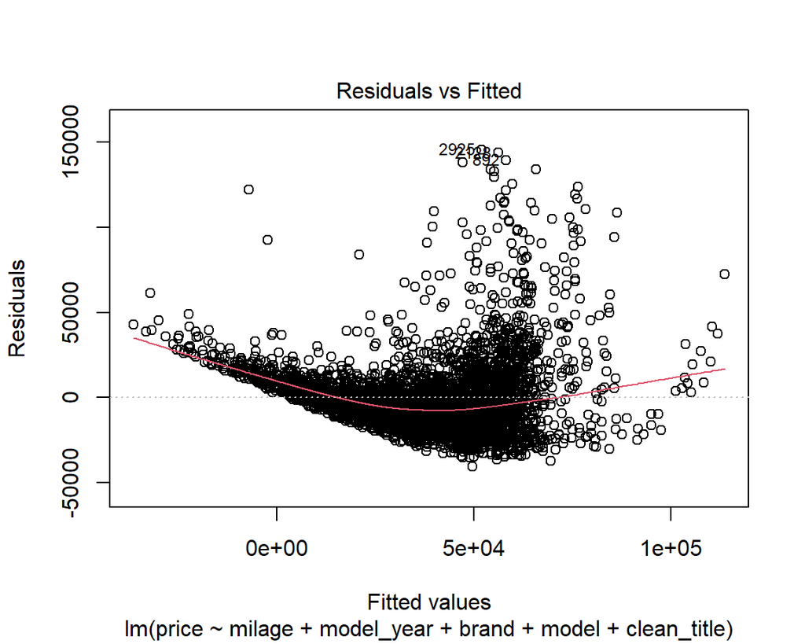

### Q-Q Residuals

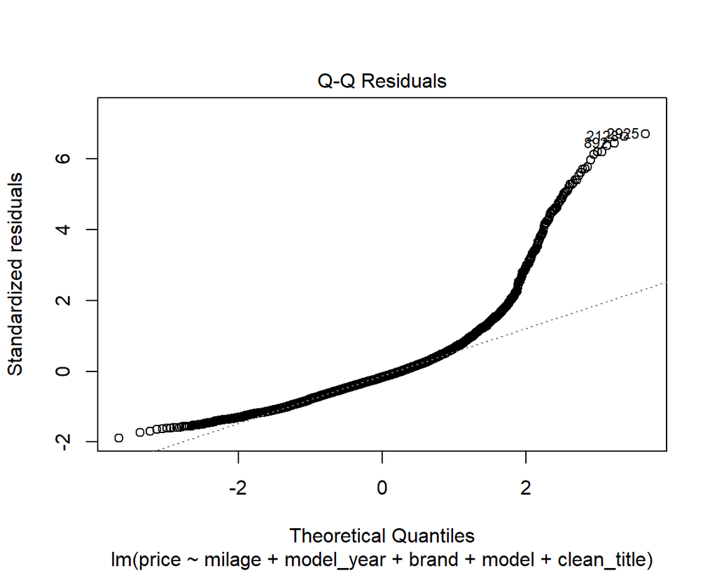